# Reproducible code for PLOS ONE Manuscript

Tesla DuBois

06/20/2024

This is the code used to produce adherence scores and graphics in the DuBois et. al. PLOS ONE manuscript, “Data-driven insights into neighborhood adherence to cancer prevention guidelines in Philadelphia” Please note that WalkScore is not able to be redistributed by the authors of the associated manuscript and is therefore missing from the provided dataset. Interested parties may request it at https://www.walkscore.com/professional/research.php. Without that variable, findings will vary from what is reported in the manuscript.

# Generate Adherence Scores

Call in and view the data dictionary and neighborhood estimates.

```r
data_dictionary <- read.csv("data_dictionary.csv")
# View(data_dictionary)

data <- read.csv("data_availability_dataset.csv")
# View(data)
```

Save out recommendation data, pivot data longer for ease of use, attach recommendation number and reverse codes from data dictionary.

```r
measures <- data%>%
  select(-c(cancer_mortality_comparison, cancer_mortality_rate))%>%# take out mortality
  pivot_longer(
    cols = !c(nbhd_id, nbhd_name),
    names_to = "measure",
    values_to = "estimate")%>% # make it longer
  left_join(data_dictionary%>%
  select(measure, rec_num, reverse)) # attach what recommendation number & reverse codes
```

Save out the quartile ranges to go into better and worse columns in Table 1.

```r
table1_quantiles <- measures%>%
  filter(!nbhd_name == "Overall Philadelphia")%>% # filter out the city overall
  group_by(measure)%>%
  summarize(Min = round(fivenum(estimate)[1], 1),
            Q1 = round(fivenum(estimate)[2], 1),
            Mean = round(fivenum(estimate)[3], 1),
            Q4 = round(fivenum(estimate)[4], 1),
            Max = round(fivenum(estimate)[5], 1),
            mean = round(mean(estimate, na.rm = T), 1),
            SD = round(sd(estimate, na.rm = T), 2))
```

## Step 1: Assign better/worse/no different to each neighborhood on each measure

```r
step1 <- measures%>%
  filter(!nbhd_name == "Overall Philadelphia")%>% # filter out the city overall
  group_by(measure)%>% # Assign better/worse/no different within each measure by quartile
  mutate(above_below = case_when(estimate > fivenum(estimate)[4]~1,
                               estimate < fivenum(estimate)[2]~-1,
                               TRUE~0),
         better_worse = above_below*reverse)
```

## Step 2: Calculate recommendation level z-scores of sums of better/worse/no different values

Each recommendation is measured using one to four variables (Manuscript Table 1 & Table 2), each with associated value of -1, 0, or 1, produced in Step 1 to indicate that the neighborhood is worse, no different, or better than the city overall on that measure. For recommendations consisting of more than one measure, we summed the associated variable values within each recommendation. We then calculated z-scores for each recommendation.

```r
# Get the sum of all measures within each recommendation for each neighborhood
step2_sums <- step1 |>
  group_by(nbhd_id, nbhd_name, rec_num)%>%
  mutate(rec_sum = sum(better_worse, na.rm = T))%>%
  select(nbhd_id, nbhd_name, rec_num, rec_sum)%>%
  distinct()

# Create a zscore of sums within each recommendation, which will be added together for total adherence to account for the extremes within each recommendation.
step2_mean_sd <- step2_sums %>%
  group_by(rec_num)%>%
  summarize(recomm_mean = mean(rec_sum, na.rm = T),
            recomm_stdev = sd(rec_sum, na.rm = T))

# Calculate z-scores
step2_zscores <- left_join(step2_sums, step2_mean_sd)%>%
  mutate(recomm_Zscore = (rec_sum - recomm_mean)/recomm_stdev)
# Save out better/worse designations within each recommendation to look at it later in high mortality neighborhoods (Tables 3 and 4)
step2_rec_betterworse <- step2_zscores%>%
  group_by(rec_num)%>%
  mutate(better_worse_rec = case_when(rec_sum > fivenum(rec_sum)[4]~1,
                               rec_sum < fivenum(rec_sum)[2]~-1,
                               TRUE~0))

# clean up
rm(step2_mean_sd, step2_sums)
```

## Step 3: Sum recommendation z-scores and designate better/worse/no different adherence to two separate indices

Step 3: Separate recommendations into two different indices: ACS Physical Activity, Nutrition and Smoking Guidelines (ACS for short) and Preventive Service Guidelines (PS for short). For each, sum the z-scores of the included recommendations within each neighborhood. Then take a new z-score of that sum. This is the final adherence score. Quartile breaks determine better/worse/no different overall adherence relative to the city overall.

```r
step3_PS_Zsum <- step2_zscores %>%
  filter(rec_num %in% c("x.1", "x.2","x.3"))%>%
  group_by(nbhd_id)%>%
  summarize(PS_zSum = sum(recomm_Zscore, na.rm = T))

step3_PS_meansd <- step3_PS_Zsum %>%
  summarize(PS_mean = mean(PS_zSum, na.rm = T),
            PS_stdev = sd(PS_zSum, na.rm = T))

# Calculate z-scores
step3_PS_zscore <- step3_PS_Zsum %>%
  mutate(PS_Zscore = (PS_zSum - step3_PS_meansd$PS_mean)/step3_PS_meansd$PS_stdev)%>%
  mutate(Adherence_PS = case_when(PS_Zscore > fivenum(PS_Zscore)[4]~"Better",
                               PS_Zscore < fivenum(PS_Zscore)[2]~"Worse",
                               TRUE~"No Diff"))%>%
  select(nbhd_id, PS_Zscore, Adherence_PS)

rm(step3_PS_Zsum, step3_PS_meansd)
```

```r
step3_ACS_sums <- step2_zscores %>%
  filter(rec_num %in% c("1", "2","3","4", "5", "6", "7"))%>%
  group_by(nbhd_id)%>%
  summarize(ACS_zSum = sum(recomm_Zscore, na.rm = T))

step3_ACS_meansd <- step3_ACS_sums %>%
  summarize(ACS_mean = mean(ACS_zSum, na.rm = T),
            ACS_stdev = sd(ACS_zSum, na.rm = T))

# Calculate z-scores
step3_ACS_zscore <- step3_ACS_sums %>%
  mutate(ACS_Zscore = (ACS_zSum - step3_ACS_meansd$ACS_mean)/step3_ACS_meansd$ACS_stdev)%>%
  mutate(Adherence_ACS = case_when(ACS_Zscore > fivenum(ACS_Zscore)[4]~"Better",
                               ACS_Zscore < fivenum(ACS_Zscore)[2]~"Worse",
                               TRUE~"No Diff"))%>%
  select(nbhd_id, ACS_Zscore, Adherence_ACS)

rm(step3_ACS_sums, step3_ACS_meansd)
```

# Test for associations with mortality

The following code was used to test for associations with overall cancer mortality. While these indices were not generated to support public health interventions rather than predict mortality, we expect to see that it is related to mortality.

NOTE: Due to restrictions on data distributions, the available data provided with this code does not include the WalkScore data that was included in calculation of recommendation 7 in the manuscript. Therefore, ACS_Zscore, PS_Zscore, Adherence_ACS, Adherence_PS, may very from results reported in the manuscript, as well as the associations with mortality that follow.

```r
# get measures and two indices and mortality all into a single data frame
final <- data %>%
  left_join(step3_ACS_zscore)%>%
  left_join(step3_PS_zscore)%>%
  filter(!nbhd_name == "Overall Philadelphia") # Take out overall Philly
```

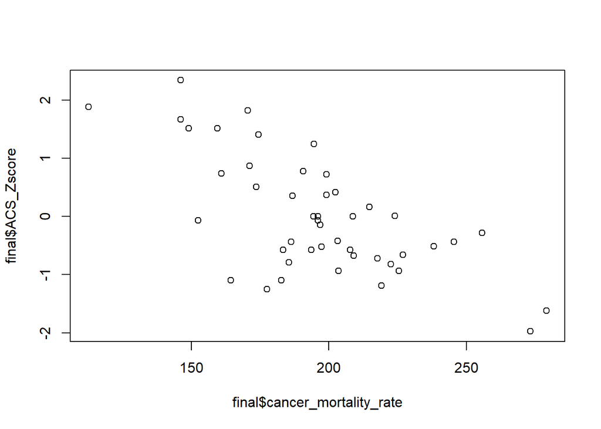

```r
# Do we have a linear relationship between cancer mortality and each of our indices?
plot(final$cancer_mortality_rate, final$ACS_Zscore) #yes
```

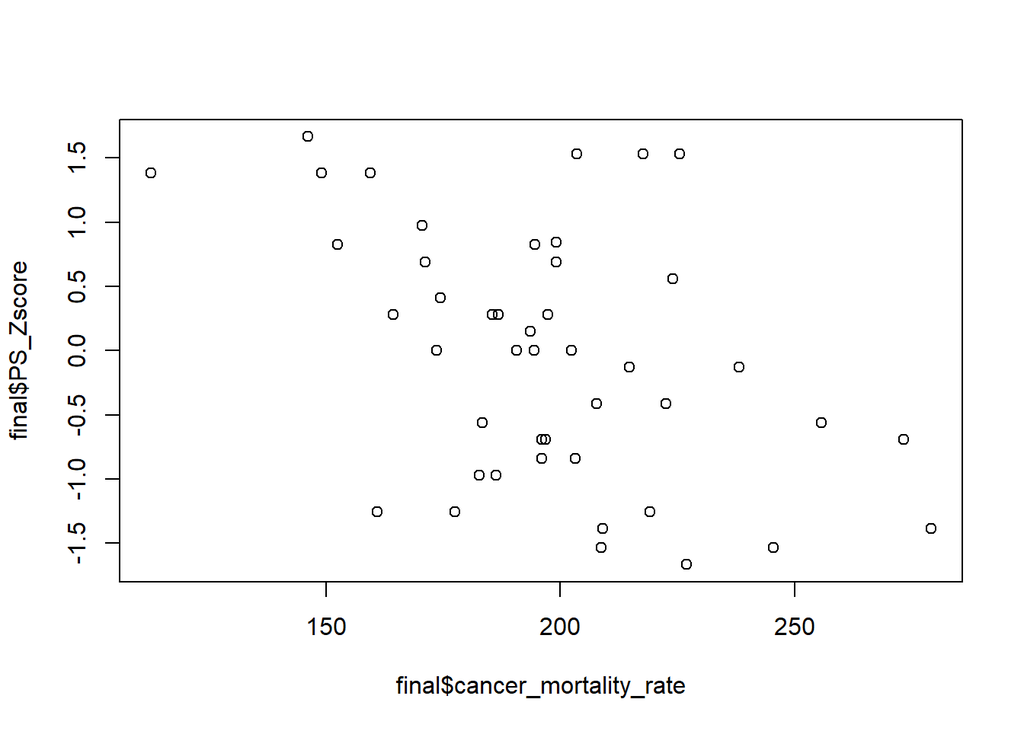

```r
plot(final$cancer_mortality_rate, final$PS_Zscore) #yes
```

```r
# Are they significantly correlated?
cor.test(final$ACS_Zscore, final$cancer_mortality_rate, method = c("spearman")) # yes
```

```
##
##  Spearman's rank correlation rho
##
## data:  final$ACS_Zscore and final$cancer_mortality_rate
## S = 25392, p-value = 4.146e-05
## alternative hypothesis: true rho is not equal to 0
## sample estimates:
##        rho
## -0.5659592
```

```r
cor.test(final$PS_Zscore, final$cancer_mortality_rate, method = c("spearman")) # yes
```

```
##
##  Spearman's rank correlation rho
##
## data:  final$PS_Zscore and final$cancer_mortality_rate
## S = 23320, p-value = 0.002322
## alternative hypothesis: true rho is not equal to 0
## sample estimates:
##        rho
## -0.4381586
```

```r
#Are they associated?
ACS_mod <- lm(cancer_mortality_rate ~ ACS_Zscore, data = final)
summary(ACS_mod) # yes
```

```
##
## Call:
## lm(formula = cancer_mortality_rate ~ ACS_Zscore, data = final)
##
## Residuals:
##     Min      1Q  Median      3Q     Max
## -56.329 -12.783  -1.319  14.670  53.334
##
## Coefficients:
##             Estimate Std. Error t value Pr(>|t|)
## (Intercept)   196.03       3.60  54.454  < 2e-16 ***
## ACS_Zscore    -22.46       3.64  -6.171 1.89e-07 ***
## ---
## Signif. codes:  0 '***' 0.001 '**' 0.01 '*' 0.05 '.' 0.1 ' ' 1
##
## Residual standard error: 24.42 on 44 degrees of freedom
## Multiple R-squared:  0.4639, Adjusted R-squared:  0.4517
## F-statistic: 38.08 on 1 and 44 DF,  p-value: 1.893e-07
```

```r
PS_mod <- lm(cancer_mortality_rate ~ PS_Zscore, data = final)
summary(PS_mod)# yes
```

```
##
## Call:
## lm(formula = cancer_mortality_rate ~ PS_Zscore, data = final)
##
## Residuals:
##     Min      1Q  Median      3Q     Max
## -61.338 -20.044  -5.778  15.962  66.280
##
## Coefficients:
##             Estimate Std. Error t value Pr(>|t|)
## (Intercept)  196.026      4.298  45.607  < 2e-16 ***
## PS_Zscore    -16.011      4.346  -3.684 0.000625 ***
## ---
## Signif. codes:  0 '***' 0.001 '**' 0.01 '*' 0.05 '.' 0.1 ' ' 1
##
## Residual standard error: 29.15 on 44 degrees of freedom
## Multiple R-squared:  0.2358, Adjusted R-squared:  0.2184
## F-statistic: 13.57 on 1 and 44 DF,  p-value: 0.000625
```

# Visualize spatial distribution of adherence indices

## Step 1: Map out adherence by neighborhood

```r
# call in the neighborhood and philly shaprefiles
nbhds <- read_sf("shapefiles/nbhds.shp")%>%
  left_join(final) # attach final data
```

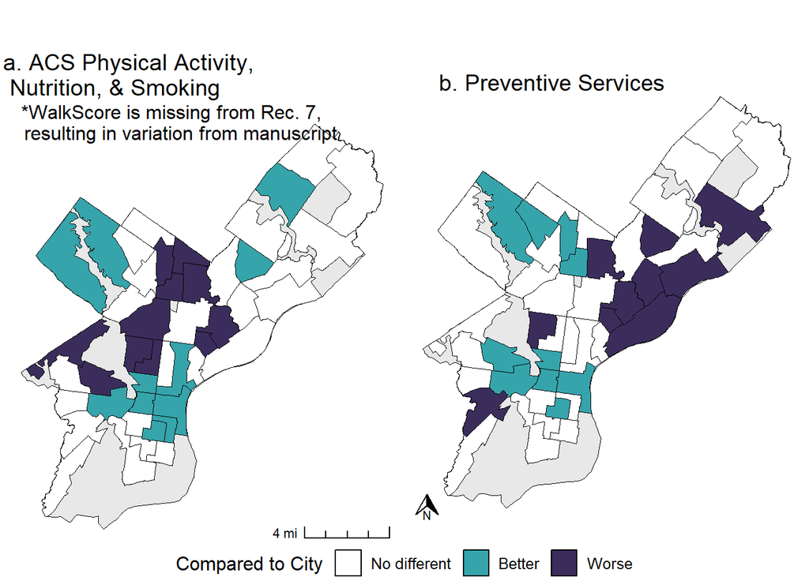

```r
philly <- read_sf("shapefiles/Philly.shp")

# Generate ACS guidelines adherence map
ACS_map <- ggplot() +
  geom_sf(philly,
          mapping = aes(),
          color = "black",
          size = 1,
          fill = "#E8E8E8")+
  geom_sf(nbhds,
          mapping = aes(fill = Adherence_ACS),
          colour = "Black")+
  labs(fill = "Value") +
  scale_fill_manual(breaks = c("No Diff", "Better", "Worse"),
                    values=c("white", "#36A4AB", "#3B2D5B"),
                    labels = c("No different", "Better", "Worse"))+
  annotation_scale(plot_unit = "ft",
                   unit_category = "imperial",
                   location = "br",
                   style = "ticks")+
  theme_void() +
  labs(title = paste0("a. ACS Physical Activity, \n Nutrition, & Smoking"),
       fill = "Compared to City",
       subtitle = "*WalkScore is missing from Rec. 7, \n resulting in variation from manuscript")+
  theme(plot.title = element_text(hjust = 0.0, vjust = -8),
        plot.subtitle = element_text(hjust = 0.2, vjust = -8.5),
        text = element_text(size = 12))

# Generate preventive services map
PS_map <- ggplot() +
  geom_sf(philly,
          mapping = aes(),
          color = "black",
          size = 1,
          fill = "#E8E8E8")+
  geom_sf(nbhds,
          mapping = aes(fill = Adherence_PS),
          colour = "Black")+
  labs(fill = "Value") +
  scale_fill_manual(breaks = c("No Diff", "Better", "Worse"),
                    values=c("white", "#36A4AB", "#3B2D5B"),
                    labels = c("No different", "Better", "Worse"))+
  annotation_north_arrow(which_north = "grid",
                         height = unit(0.5, "cm"),
                         width = unit(0.5, "cm"),
                         pad_x = unit(0.25, "cm"),
                         pad_y = unit(0.25, "cm"),
                         style = north_arrow_orienteering(fill = c("white", "black"),
                                                          text_size = 6),
                         location = "bl") +
  theme_void() +
  labs(title = paste0("b. Preventive Services \n                       "),
       fill = "Compared to City") +
  theme(plot.title = element_text(hjust = 0.2, vjust = -8),
        plot.subtitle = element_text(hjust = 0.2, vjust = -8.5),
        text = element_text(size = 12))

# Display them side by side
AdherenceMaps <- ggarrange(plotlist = list(ACS_map, PS_map),
                     common.legend = TRUE,
                     legend = "bottom",
                     ncol = 2, nrow = 1,
                     widths = c(8,8), heights = (12))

AdherenceMaps
```

## Step 2: Observe overlap between worse adherence and worse mortality

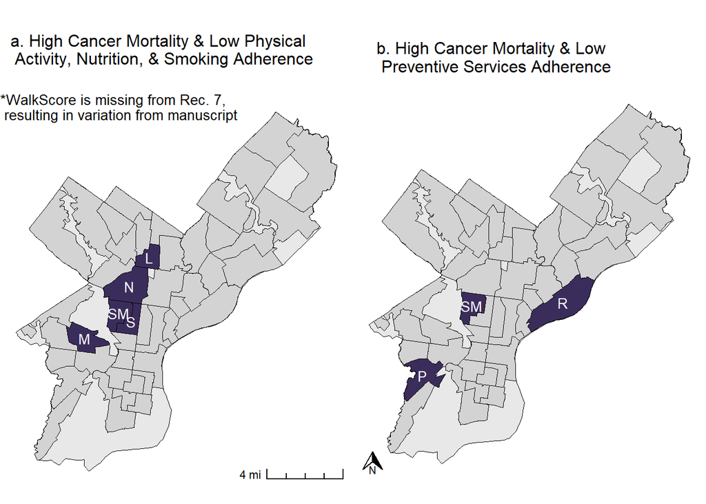

```r
# For ACS Guidelines
worst_worst_ACS <- nbhds |>
  filter(cancer_mortality_comparison == "Worse" & Adherence_ACS == "Worse")|>
   mutate(initial = ifelse(nbhd_name == "Strawberry Mansion", "SM", substr(nbhd_name,1,1)))

# For Preventive Services Guidelines
worst_worst_PS <- nbhds |>
  filter(cancer_mortality_comparison == "Worse" & Adherence_PS == "Worse")|>
   mutate(initial = ifelse(nbhd_name == "Strawberry Mansion", "SM", substr(nbhd_name,1,1)))

# Map ACS
worst_worst_ACS_map <- ggplot() +
  geom_sf(philly, mapping = aes(),
          color = "black",
          size = 1,
          fill = "#E8E8E8")+
  geom_sf(nbhds,
          mapping = aes(),
          colour = "Black",
          fill = "lightgray")+
  geom_sf(worst_worst_ACS,
          mapping = aes(),
          colour = "Black",
          fill = "#3B2D5B")+
  geom_sf_text(worst_worst_ACS,
               mapping = aes(label = initial),
               size=3.5, color = "white",
               fun.geometry = sf::st_centroid) +
  annotation_scale(plot_unit = "ft",
                   unit_category = "imperial",
                   location = "br",
                   style = "ticks")+
  theme_void() +
  labs(title = paste0("a. High Cancer Mortality & Low Physical \n Activity, Nutrition, & Smoking Adherence"),
       fill = "Mortality Rate",
       subtitle = "*WalkScore is missing from Rec. 7, \n resulting in variation from manuscript") +
  theme(plot.title = element_text(hjust = 0.2, vjust = -2),
        legend.position.inside = c(0.9, 0.2),
        plot.subtitle = element_text(hjust = 0.0, vjust = -8.5),
        text = element_text(size = 10))

# Map PS
worst_worst_PS_map <- ggplot() +
  geom_sf(philly, mapping = aes(),
          color = "black",
          size = 1,
          fill = "#E8E8E8")+
  geom_sf(nbhds, mapping = aes(),
          colour = "Black",
          fill = "lightgray")+
  geom_sf(worst_worst_PS,
          mapping = aes(),
          colour = "Black",
          fill = "#3B2D5B")+
  annotation_north_arrow(which_north = "grid",
                         height = unit(0.5, "cm"),
                         width = unit(0.5, "cm"),
                         pad_x = unit(0.25, "cm"),
                         pad_y = unit(0.25, "cm"),
                         style = north_arrow_orienteering(fill = c("white", "black"),
                                                          text_size = 6),
                         location = "bl") +
  theme_void() +
  geom_sf_text(worst_worst_PS,
               mapping = aes(label = initial),
               size=3.5, color = "white",
               fun.geometry = sf::st_centroid) +
  labs(title = paste0("b. High Cancer Mortality & Low \n Preventive Services Adherence"),
       fill = "Mortality Rate",
       subtitle = "                                     ") +
  theme(plot.title = element_text(hjust = 0.2, vjust = -2),
        legend.position.inside = c(0.9, 0.2),
        plot.subtitle = element_text(hjust = 0.2, vjust = -8.5),
        text = element_text(size = 10))

# Display them side by side
MortalityMaps <- ggarrange(plotlist = list(worst_worst_ACS_map, worst_worst_PS_map),
                           common.legend = TRUE,
                           legend = "bottom",
                           ncol = 2, nrow = 1,
                           widths = c(15, 15))
MortalityMaps
```

## Step 3: Identify which recommendations are worse in the neighborhoods with high mortality and low adherence

This doesn’t match the manuscript because this public version is missing WalkScore, but the code below corresponds with Tables 3 and 4.

```r
worse_worse_ACS_recs <- step2_rec_betterworse%>%
  filter(nbhd_name%in%unique(worst_worst_ACS$nbhd_nm))%>%
  select(nbhd_name, rec_num, better_worse_rec)%>%
  pivot_wider(names_from = nbhd_name,
              id_cols = rec_num,
              values_from = better_worse_rec)%>%
  filter(rec_num%in%c("1", "2","3","4", "5", "6", "7"))%>%
  left_join(data_dictionary%>%
              select(rec_num, recommendation)%>%
              distinct()
            )%>% # bring the recommendation description in
  relocate(recommendation)
autofit(flextable(worse_worse_ACS_recs)%>%
  delete_columns(2)) # hide rec_num from display
```

| recommendation | Mill Creek - Parkside | Strawberry Mansion | Sharswood - Stanton | Nicetown - Tioga | Logan |
| --- | --- | --- | --- | --- | --- |
| #1- Achieve and Maintain a Healthy Weight Throughout Life | 0 | -1 | 0 | -1 | -1 |
| #2- Be Physically Active | 0 | -1 | 0 | -1 | 0 |
| #3- Eat a Healthy Diet, with an Emphasis on Plant Foods | -1 | 0 | 0 | -1 | -1 |
| #4- Limit Intake of Alcohol | 0 | 0 | -1 | 0 | 1 |
| #5- Stay Away from Tobacco | 0 | -1 | 0 | -1 | 0 |
| #6- Increase access to affordable, nutritious foods | 0 | 0 | 0 | 0 | -1 |
| #7- Provide safe, enjoyable, and accessible environments for physical activity in schools and workplaces, and for transportation and recreation in communities | -1 | -1 | -1 | -1 | 0 |

```r
worse_worse_PS_recs <- step2_rec_betterworse%>%
  filter(nbhd_name%in%unique(worst_worst_PS$nbhd_nm))%>%
  select(nbhd_name, rec_num, better_worse_rec)%>%
  pivot_wider(names_from = nbhd_name,
              id_cols = rec_num,
              values_from = better_worse_rec)%>%
  filter(rec_num%in%c("x.1", "x.2", "x.3"))%>%
  left_join(data_dictionary%>%
              select(rec_num, recommendation)%>%
              distinct()
            )%>% # bring the recommendation description in
  relocate(recommendation)
autofit(flextable(worse_worse_PS_recs)%>%
  delete_columns(2)) # hide rec_num from display
```

| recommendation | Paschall - Kingsessing | Strawberry Mansion | Richmond - Bridesburg |
| --- | --- | --- | --- |
| Health-specific #1: Increase the proportion of adults who self-report good or better health | -1 | -1 | 0 |
| Health-Specific #2: Provide population-based primary prevention services | -1 | -1 | -1 |
| Health-specific #3: Screening | 0 | 0 | -1 |

# Supplemental Maps

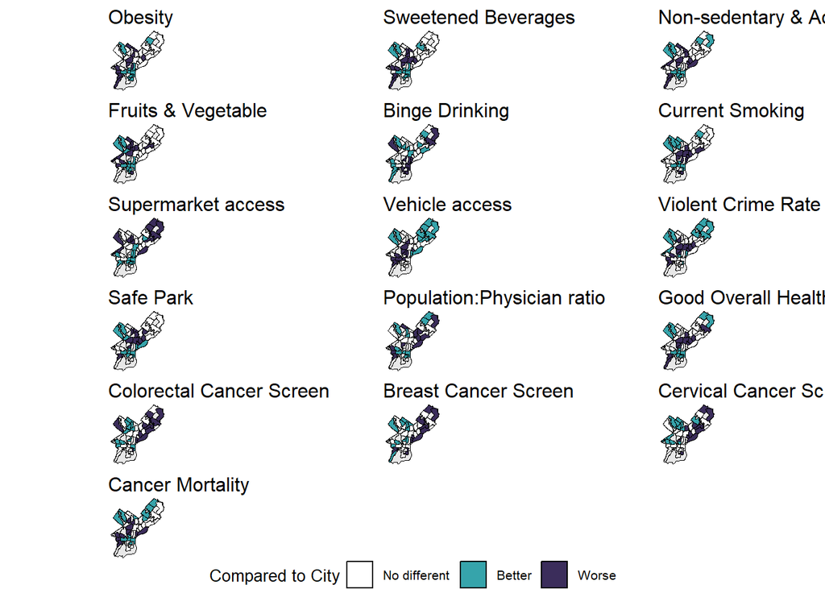

```r
# Get labels ready to use as map titles
labels <- c("Obesity", "Sweetened Beverages", "Non-sedentary & Active",
            "Fruits & Vegetable", "Binge Drinking", "Current Smoking",
            "Supermarket access", "Vehicle access", "Violent Crime Rate", "Safe Park",
            "WalkScore", "Population:Physician ratio", "Good Overall Health",
            "Colorectal Cancer Screen", "Breast Cancer Screen", "Cervical Cancer Screen",
            "Cancer Mortality")

# Prep spatial data set with better/worse indicators for all measures and mortality
nbhd_bw_measures <- nbhds%>%
  left_join(step1%>%pivot_wider(id_cols = c(nbhd_id, nbhd_name), names_from = measure,
                          values_from = better_worse, names_prefix = "bw_"))%>%
  mutate(bw_cancer_mortality = case_when(cancer_mortality_comparison == "No Different"~"0",
                                                 cancer_mortality_comparison == "Better"~"1",
                                                 cancer_mortality_comparison == "Worse"~"-1"))
# Make a function for making maps
make_risk_map <- function(variable, label){
  ggplot() +
  geom_sf(philly,
          mapping = aes(),
          color = "black",
          size = 1,
          fill = "#E8E8E8")+
  geom_sf(nbhd_bw_measures,
          mapping = aes(fill = as.character(variable)),
          colour = "Black")+
  labs(fill = "Value") +
  scale_fill_manual(breaks = c("0", "1", "-1"),
                    values=c("white", "#36A4AB", "#3B2D5B"),
                    labels = c("No different", "Better", "Worse"))+
  theme_void() +
  labs(title = paste0(label),
       fill = "Compared to City") +
  theme(text = element_text(size = 10))
}

# Apply the function to all measures and mortality, calling the lables established above
obese_map <- make_risk_map(nbhd_bw_measures$bw_obese, labels[1])
soda_juice_1d_map <- make_risk_map(nbhd_bw_measures$bw_soda_juice_1d, labels[2])
nonsedent_map <- make_risk_map(nbhd_bw_measures$bw_nonsedent, labels[3])
fruit5_map <- make_risk_map(nbhd_bw_measures$bw_fruit5, labels[4])
binge_map <- make_risk_map(nbhd_bw_measures$bw_binge, labels[5])
smoker_map <- make_risk_map(nbhd_bw_measures$bw_smoker, labels[6])
food_halfmile_map <- make_risk_map(nbhd_bw_measures$bw_food_halfmile, labels[7])
HH_vehicle_map <- make_risk_map(nbhd_bw_measures$bw_HH_vehicle, labels[8])
crime_per_100k_map <- make_risk_map(nbhd_bw_measures$bw_crime_per_100k, labels[9])
havepark_map <- make_risk_map(nbhd_bw_measures$bw_havepark, labels[10])
# walkscore_map <- make_risk_map(nbhd_bw_measures$bw_walkscore, labels[11]) # Not available
poppcp_ratio_map <- make_risk_map(nbhd_bw_measures$bw_poppcp_ratio, labels[12])
healthgood_map <- make_risk_map(nbhd_bw_measures$bw_healthgood, labels[13])
colsig10y_map <- make_risk_map(nbhd_bw_measures$bw_colsig10y, labels[14])
mam2y_map <- make_risk_map(nbhd_bw_measures$bw_mam2y, labels[15])
pap3y_map <- make_risk_map(nbhd_bw_measures$bw_pap3y, labels[16])
mort <- make_risk_map(nbhd_bw_measures$bw_cancer_mortality, labels[17])

# Display maps together
RiskMaps <- ggarrange(plotlist = list(obese_map, soda_juice_1d_map, nonsedent_map,
                                      fruit5_map, binge_map, smoker_map, food_halfmile_map,
                                      HH_vehicle_map, crime_per_100k_map, havepark_map,
                                      #walkscore_map, # missing from data availablity
                                      poppcp_ratio_map, healthgood_map,
                                      colsig10y_map, mam2y_map, pap3y_map, mort),
                      common.legend = TRUE,
                      legend = "bottom",
                      ncol = 3, nrow = 6)

RiskMaps
```